# ISM Honours Information and Knowledge in Organisations Data Analysis Assignment 2: Data Collection and Text Mining

Christian Muller & Gilliam van der Merwe

# Background Information and Report Outline:

This is a professional data analysis report documenting the Coronavirus, also known as Covid-19, in relation to its spread in South Africa within a timeframe of 6 months. The aim of this report is to showcase insights gathered through the acquisition and processing of tweets from applicable media agencies, facilitated by the social media platform Twitter. The result, will reflect a body of information structured in a manner reflecting that of:

1. Background Information and Introduction
2. Data acquisition and Reasoning: a) data read ins b) and data cleaning with pre-processing.
3. Report Results consisting of a) individual data source justification and plot descriptions b) with further implementation of various text analysis tools.

A total of ten media sources were selected initially. Each undergoing a mixture of analysis using a variety of data/text analysis tools and means of visualisation. The information displayed were gathered and formulated through consulting the latest 3200 tweets of the official media agency Twitter accounts described below. In processing these tweets, six introductory insights were chosen to express the information gathered namely, Frequency of Tweets, Most Liked Tweets, Top Hashtags, Most Frequently Shared Tweets, Top Mentions and Top words. This process, using these predetermined six insights will be repeated but within the context of all ten media sources.

It is imperative to note, that after careful consideration it was decided upon to only use six media sources for further analysis. This decision was made based on the results cultivated through the six insights presented above. These media sources are Bhekisisa, NICD, Health24, HealthZA, News24 and eNCA.The author -based text network described later in this report uses all 10 media accounts, but other than that, all other analysis tools are limited to using only the chosen six media accounts.

## South African Twitter’s Trending Hashtags

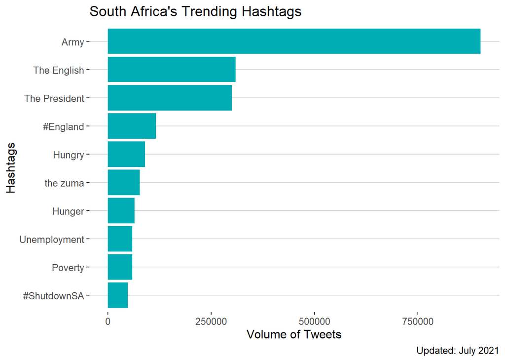

At present, there is no trending hashtag that directly pertains to the COVID-19 pandemic, rather instead most hashtags pertain to the political and social happening in Gauteng and KwaZulu-Natal due to Jacob Zuma’s arrest. Hashtags that can indirectly be attributed to the pandemic include “hunger” and “poverty” due to the economic impact of the pandemic and lockdown regulations.

# How and where data is collected:

In acquiring the needed tweets with meta-data, Twitter API V1 was utilised. The resulting data frames undergo processing towards the desired output.

The data used in this report was acquired from a variety of news media Twitter accounts, as well as Covid-19 vaccination data from the Mediahack group. The Twitter account data was acquired with the use of the Twitter API via the `twitterR` and `rtweet` packages in R. The accounts’ tweet data was first obtained using the `get_timeline()` function, thereafter the data was saved by using the `saveRDS()` function. The data was saved so that while the analyses were conducted, the changes in Twitter data would not interfere with the report. The saved account tweet data was then read in and stored by using the `readRDS()` function.

## Reading in and saving Twitter account timelines

## Cleaning and Pre-processing Data:

Each media source’s tweet data was pre-processed and cleaned. This was done by first creating a corpus of the tweet data, then un-nesting the tokens of the text variable, thereafter we removed stop words, punctuation, and other unnecessary words such as “https, http, rt, t.co and amp”. The cleaned data was then filtered and sorted depending on the type of analysis we conducted.

# Report Results:

## Minimum Requirements:

## BHEKISISA (@Bhekisisa_MG)

Bhekisisa is an independent Centre for Health Journalism. The information conveyed through them is used and published by numerous other accredited news sources and media agents. The COVID-19 virus is a pandemic, which concerns the healthcare sector of South Africa as a whole, the role of Bhekisisa as an informative platform seems imperative within this context.

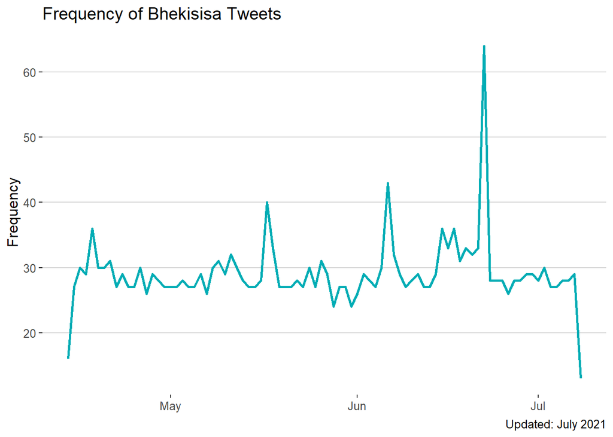

In the last month, there has not been any significant changes in the frequency of tweets by Bhekisisa. Except for a rapid spike at the end of June, which could have a correlation to the Covid-19 third wave.

1st most liked tweet of Bhekisisa was a tweet concerning a Covid -19 webinar hosted by Bhekisisa, with the host being their Editor-in-chief, Mia Malan. 2nd Most liked tweet is a tweet concerning the induction of a new type of ATM machine, which is not relevant to this report. 3rd being a tweet mentioning the Bhekisisa hosted webinar regarding the Covid pandemic with a section mentioning covid vaccination sites. The 4th most liked tweet conveyed information pertaining national Covid statistics and the 5th described the situation regarding Johnson & Johnson vaccinations for teachers.

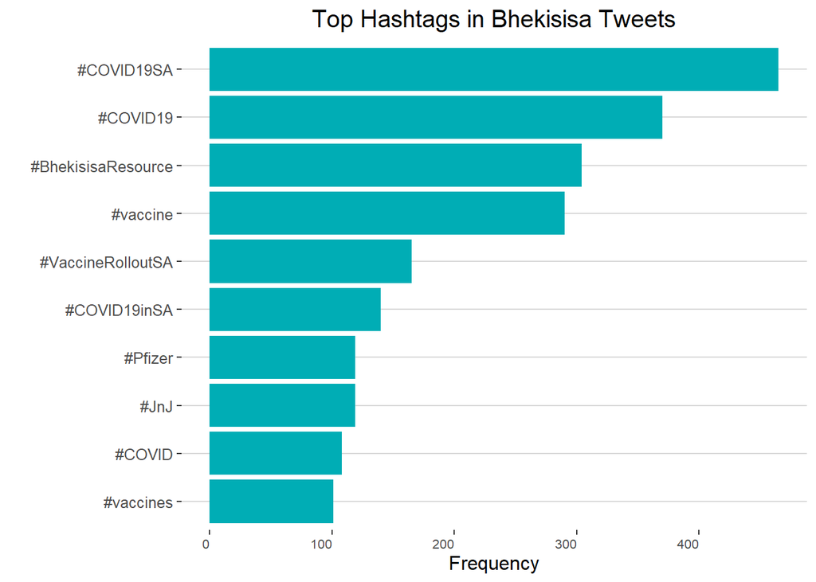

Top hashtags of Bhekisisa are structured as follows: 1. ‘#COVID19SA’, 2. ‘#COVID19’, 3. ‘#BhekisisaResource’, 4. ‘#vaccine’, 5. ‘#VaccineRolloutSA’ 6. ‘#COVID19inSA’, 7. ‘#Pfizer’, 8. ‘#JnJ’ 9. ‘#COVID’, 10. ‘#vaccines’.

The most shared tweet by Bhekisisa is a tweet concerning abortion activism, and as such can be deemed insignificant.

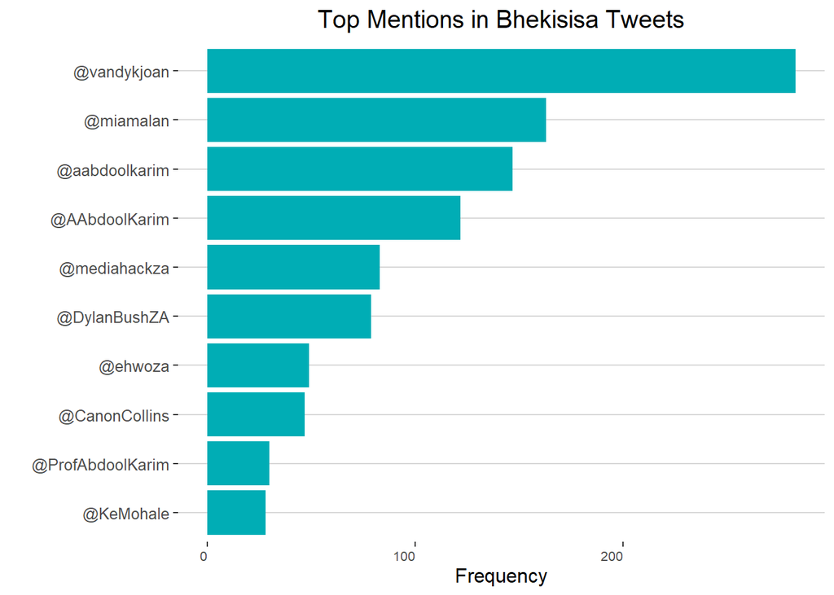

The top mention of @Bhekisisa_MG is that of a Bhekisisa reporter named Joan van Dyk (@vandykjoan), second being ‘@miamalan’. The 3rd and 4th referring to Professor Abdool Karim, who can be viewed as the face of Covid related science in South Africa.

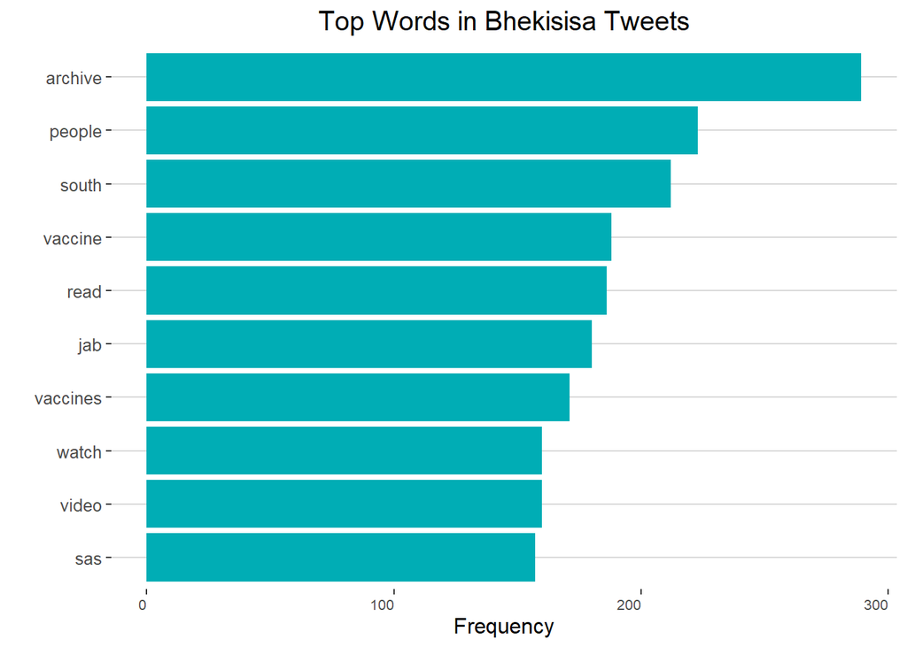

## National Institute of Communicable Diseases (@nicd_sa)

The National Institute for Communicable Diseases (NICD) is a South African National public health institute. Its’ actions are determined by the South African government, reflecting means of response, monitoring, training, diagnostics, and research of communicable diseases. One of its main purposes being outbreak response and surveillance.

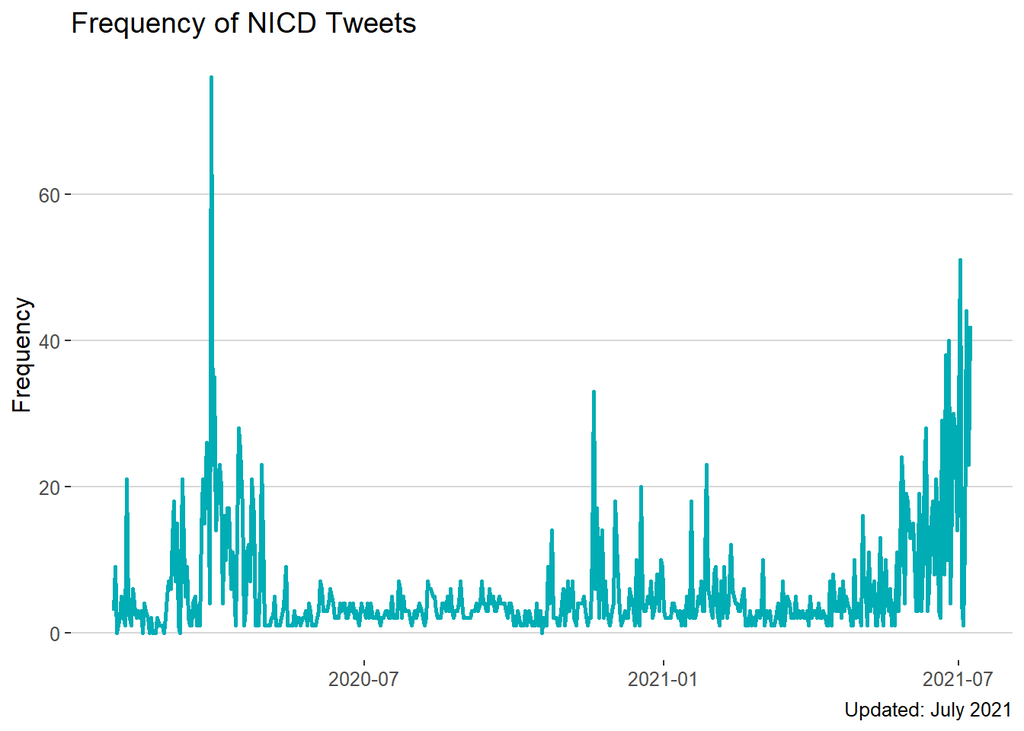

NICD’s most liked tweet contains information regarding the initial outbreak of the SARS-CoV-2 virus, also referred to as covid-19. The 2nd most liked tweet from the NICD account is a tweet praising SA’s frontline health workers in the struggle against the Covid-19 outbreak. The third most liked tweet is a tweet signalling the early increase of confirmed cases within South Africa. The fourth most liked tweet indicates the confirmed cases within South Africa reaching 1505. The 5th most liked tweet is another informative tweet on the growing number of confirmed cases in South Africa.

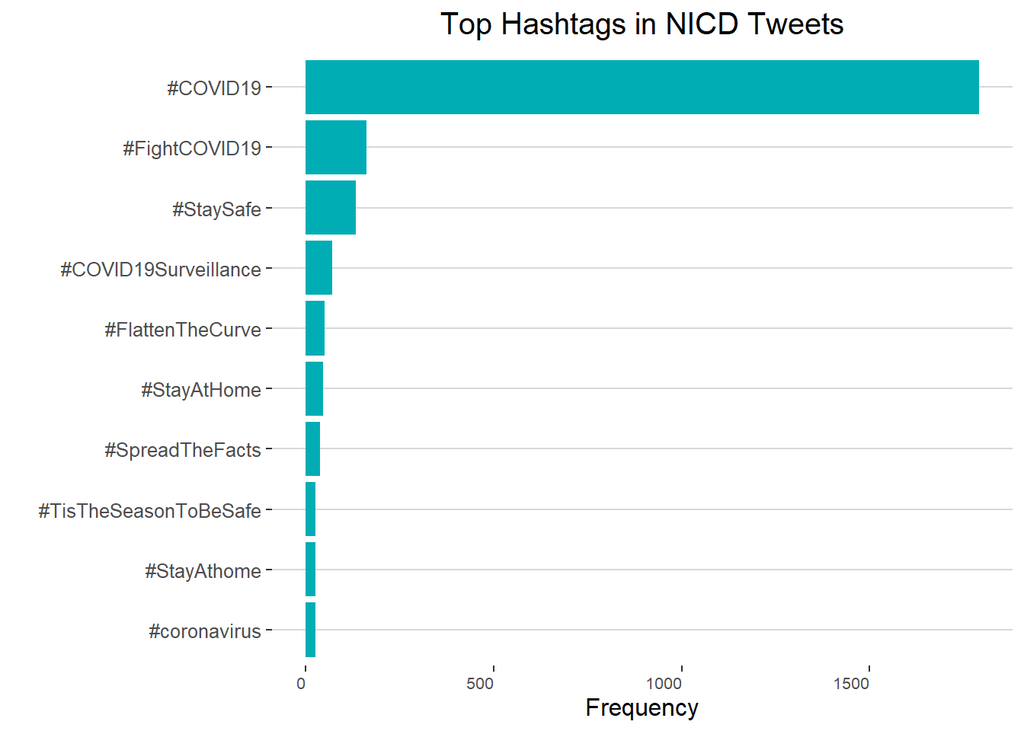

The most frequently shared tweet contains information about the rising confirmed cases of COVID-19, at 402 confirmed cases.

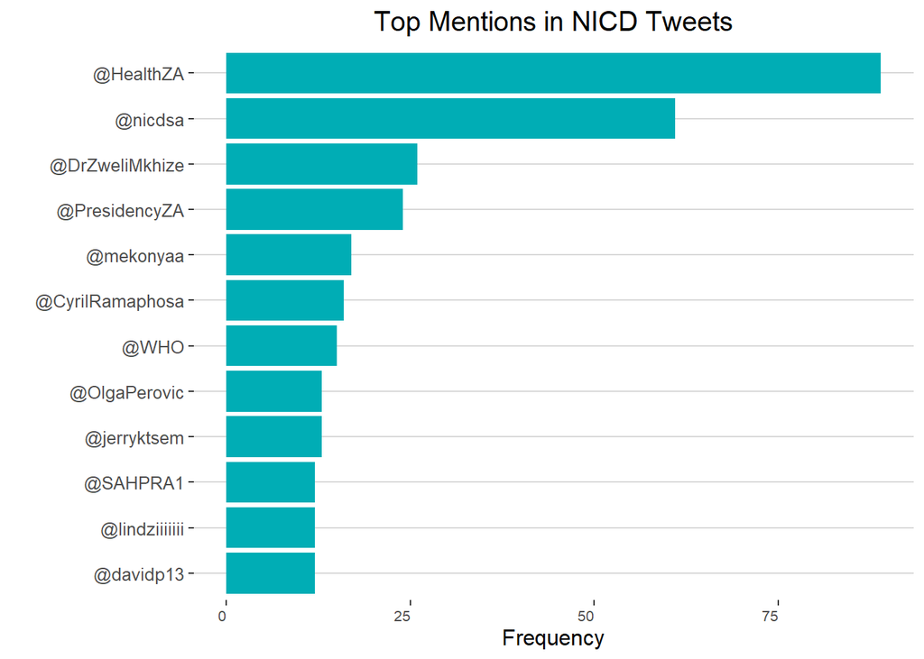

The NICD is a major provider of national health information with ‘@HealthZA’ (SA Department of Health) being the most frequent mention within their tweets. Followed by ‘ @nicdsa’ and ‘@DrZweliMkhize’, the National Minister of Health, at the time. The ‘@WHO’ and ‘@SAHPRA1’, two significant Covid-19 related institutes, one being national and the other international.

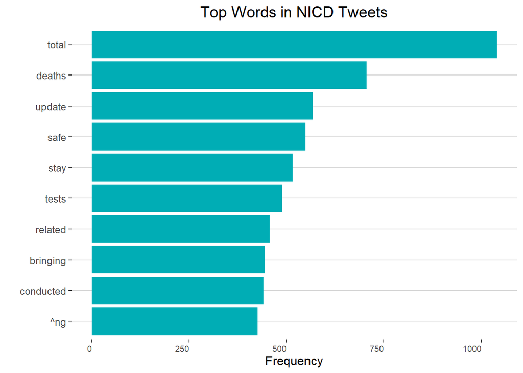

## South African Department of Health (@HealthZA)

The South African Department of Health is an organizational sector within the South African government concerned with all aspects of national health. The executive department consists of several committees and councils all with the main goal of increasing the health status of the South African citizen.

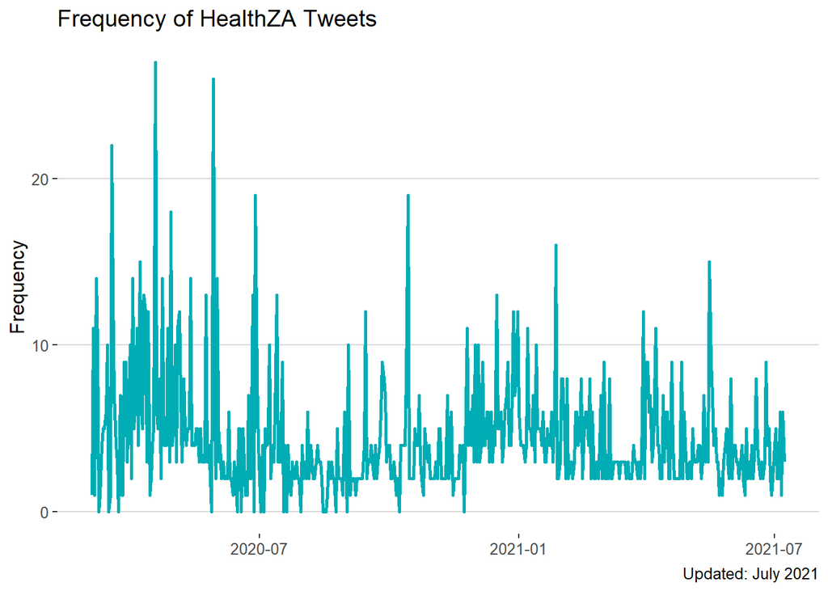

The frequency of HealthZA tweets do not showcase any noteworthy information.

1st Most liked Tweet is that of a message from SA’s Department of Health announcing that there are recoveries among reported Covid-19 cases. The 2nd referring to international help in SA’s COVID-19 cause, especially that of Cuban medical staff. The 3rd tweet informing the public on details about the second reported covid-related death in SA. The 4th giving an update on confirmed and recovered cases, followed by the 5th which contains information on the spread of Covid through social interactions.

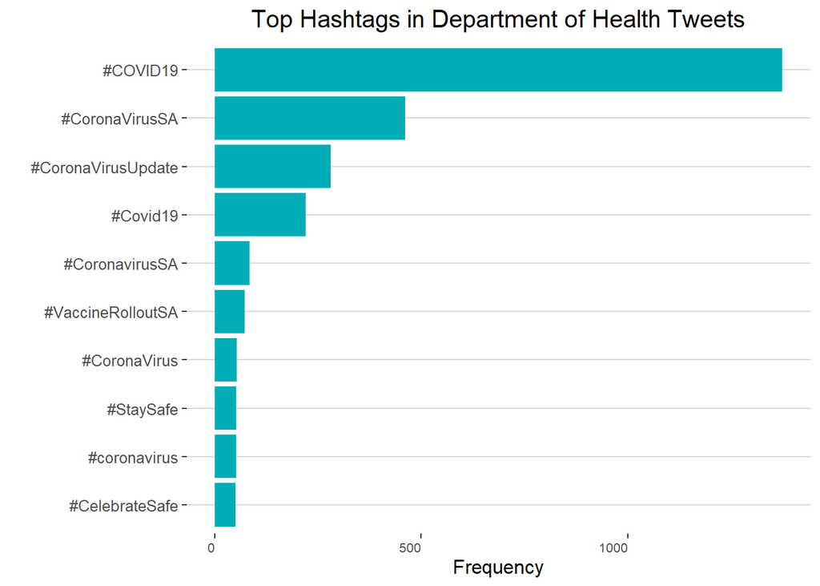

Top hashtags are structured as follows: 1. ‘#COVID19’, 2. ‘#CoronaVirusSA’, 3. ‘#CoronaVirusUpdate’, 4. ‘#Covid19’, 5. ‘#CoronavirusSA’ 6. ‘#VaccineRolloutSA’, 7. ‘#CoronaVirus’, 8. ‘#StaySafe’ 9. ‘#coronavirus’, 10. ‘#CelebrateSafe’.

The Department of Health’s most shared tweet is an announcement telling citizens who were part of certain cruise trips to contact the department as soon as possible.

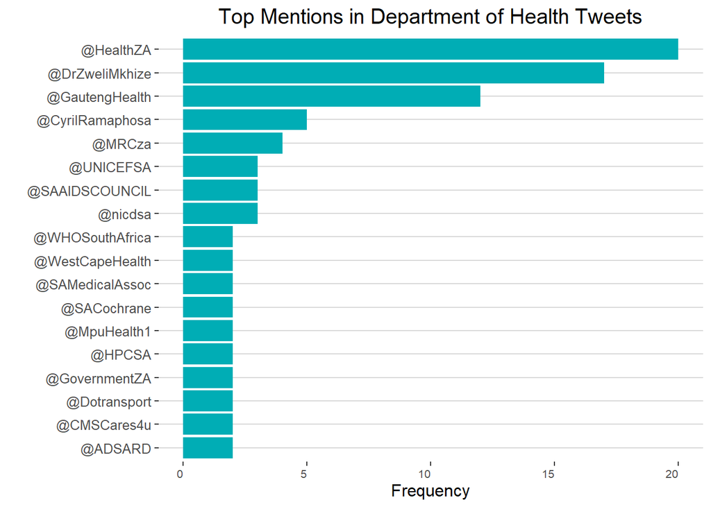

‘@GautengHealth’ is among the top five mentions of HealthZA tweets, this is referring to the current severity of the lockdown within the province. Among those in the top 10 mentions are, ‘@CyrilRamaphosa’, ‘@MRCza’, ‘@UNICEFSA’, @nicdsa’, ‘@WHOSouthAfrica’ and ‘@WestCapeHealth’. All these mentions can be related to the Covid-19 pandemic.

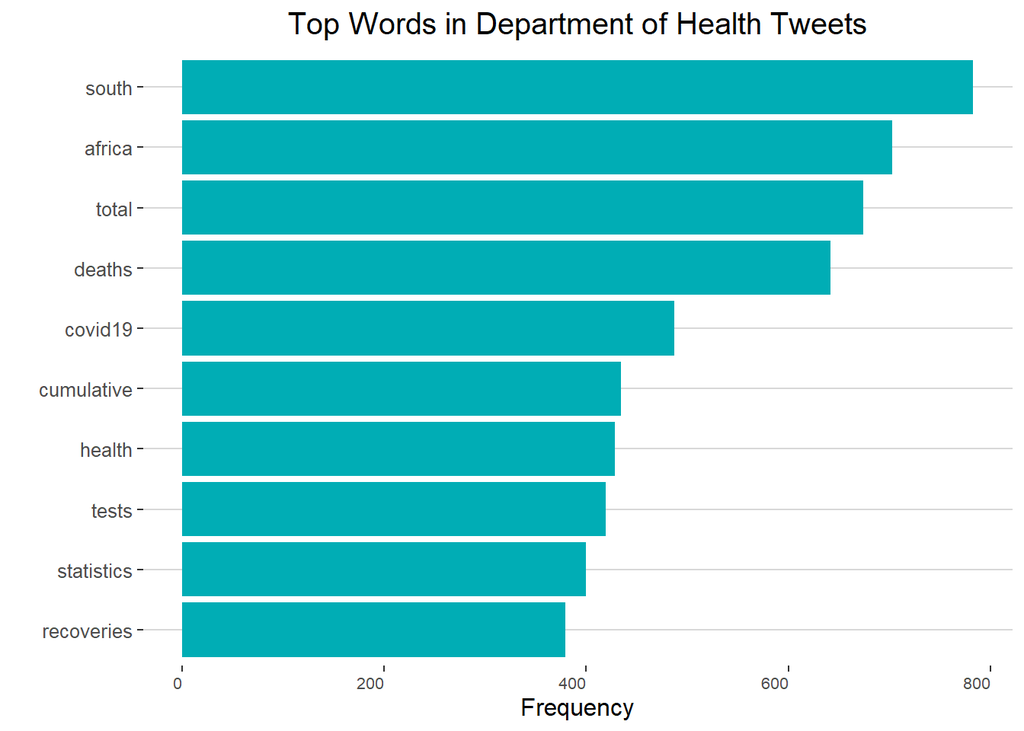

The most frequent word is ‘south’ followed by ‘africa’. The logical reasoning for this would be that most tweets would contain these two terms as the account holder is the National Department of Health. The 3rd term is ‘total’ followed by ‘deaths’, as covid statistics are released through this channel. The 5th most frequent word is ‘covid19’ and the 8th is ‘tests’.

## Eye Witness News (@ewnreporter)

Eye Witness News is a South African news agency covering media on a broad base of applicable industries and sectors.

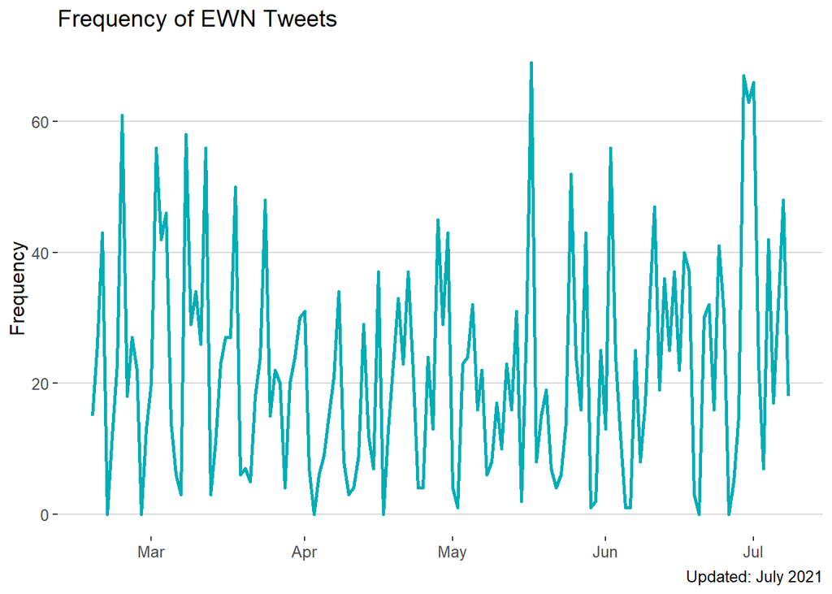

Time series of the frequency of tweets by EWN indicates that on average the account tweets in a volatile manner.

None of the most liked tweets of the EWN Twitter account are related to COVID and as such is deemed irrelevant.

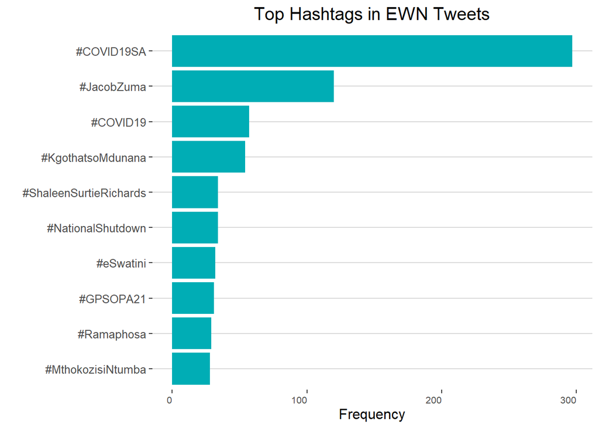

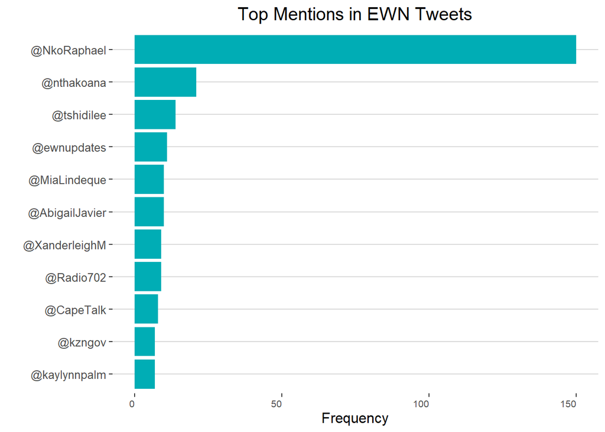

The top mentions in EWN tweets are unrelated to Covid-19.

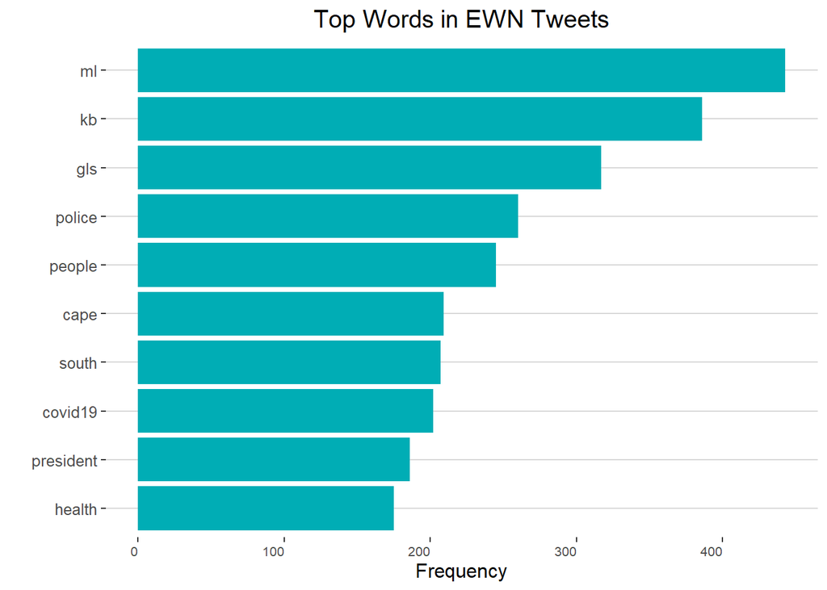

## NEWS24 (@News24)

News24 is on of South Africa’s most prominent online news platforms and was launched in 2007.

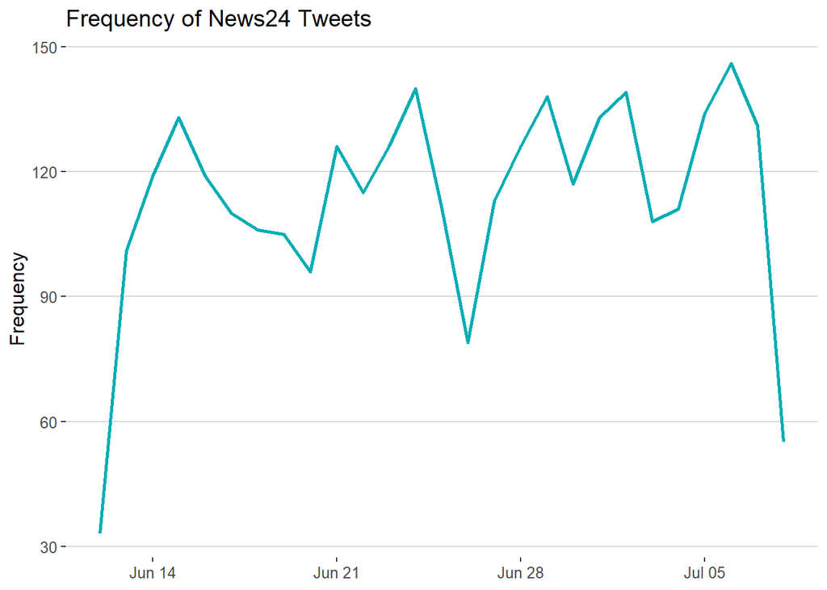

The most liked tweet is unrelated to COVID-19, including the 2nd, 3rd,4th and 5th.

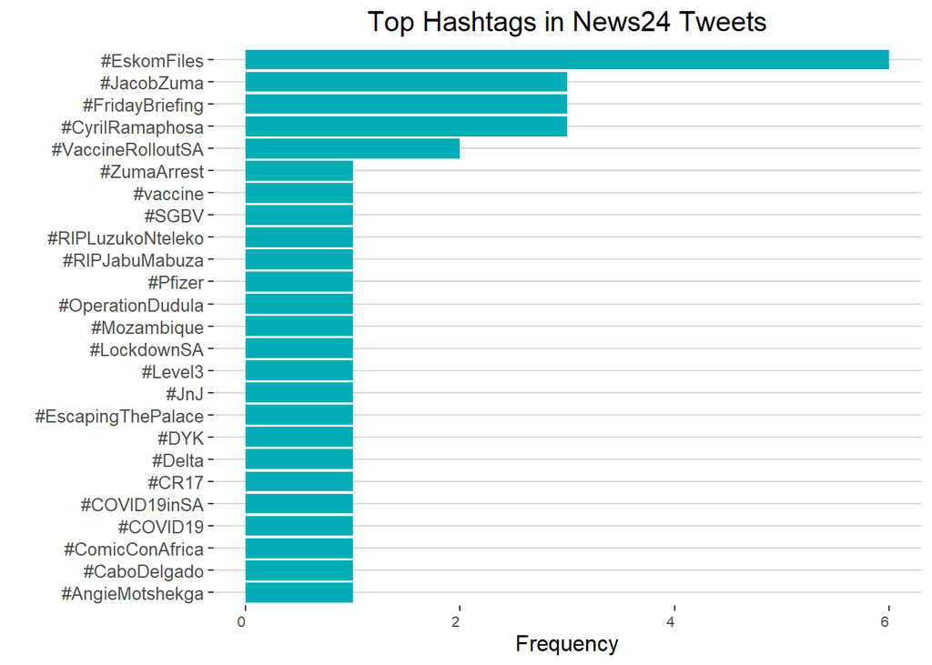

The most frequently shared tweet of News24 is unrelated to covid-19.

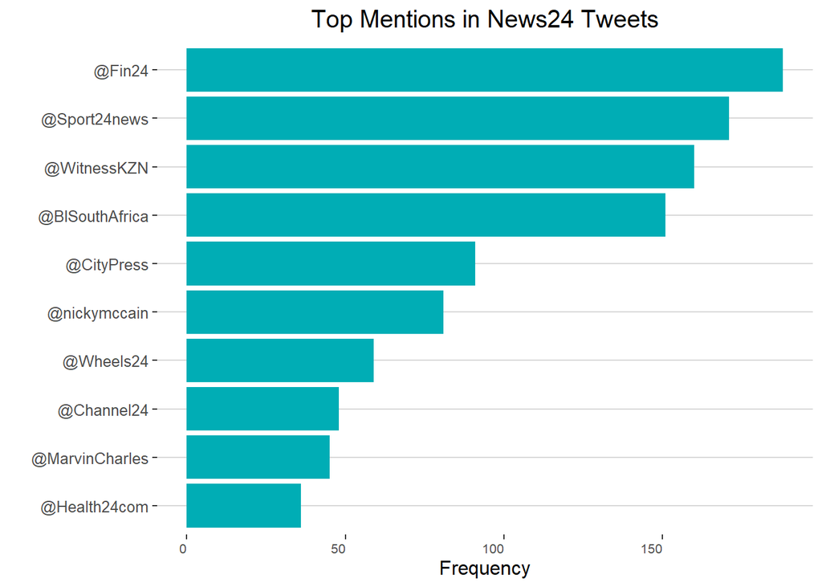

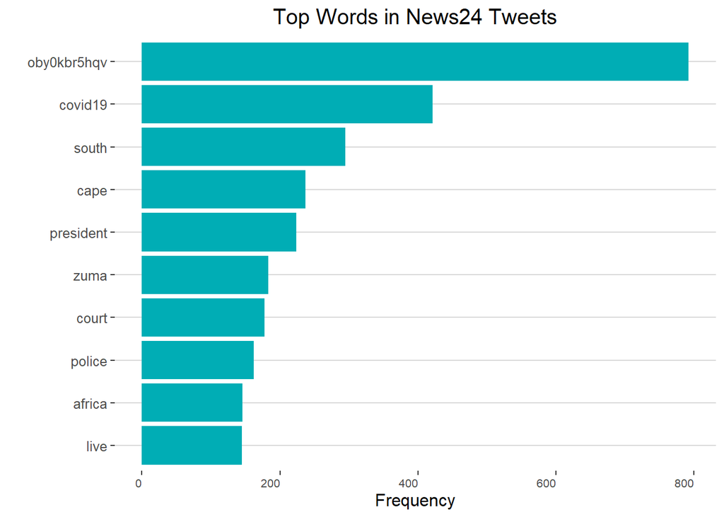

## SABC News (@SABCNews)

The SABC News account was chosen because it is the official Twitter-based digital platform used by the South African Broadcasting Corporation, which is one of the most popular and reputable news media sources in South Africa.

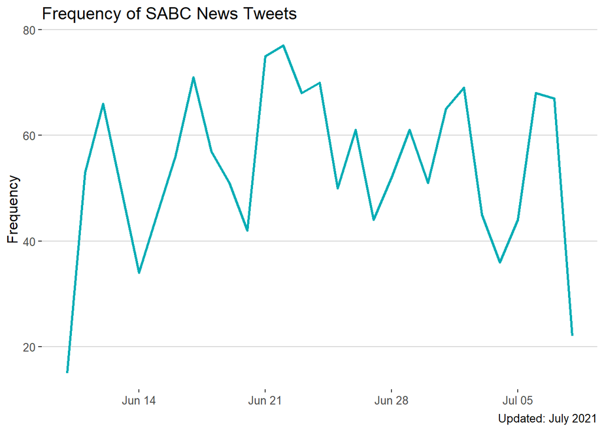

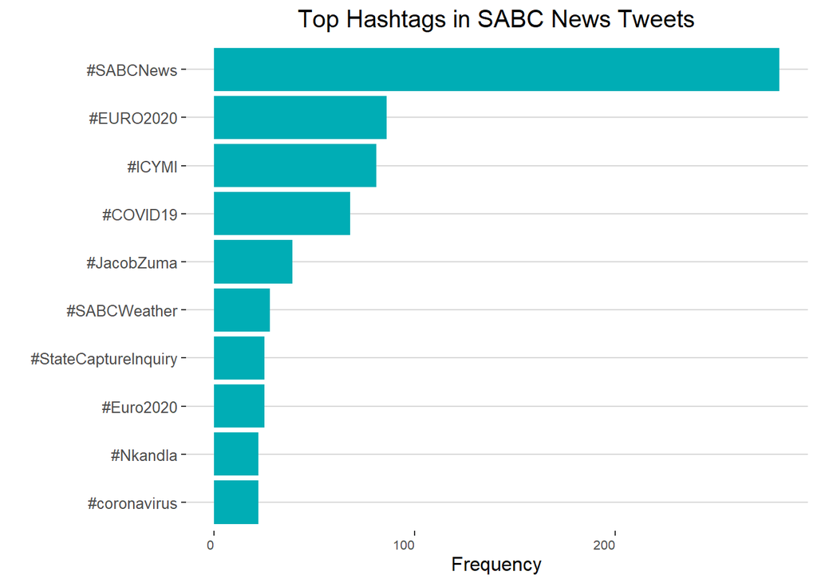

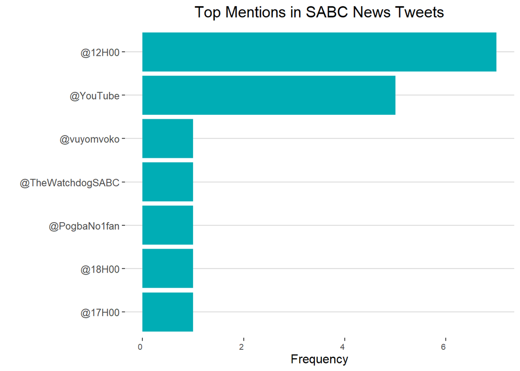

The bar chart showing the top mentions in SABC News Tweets indicates that the most frequent mentions are “@12H00”, “@YouTube”, “@17H00”, “@18H00”, “@PogbaNo1fan”, “@TheWatchdogSABC” and “@vuyomvoko”. The mentions do not provide any insight about the COVID-19 pandemic.

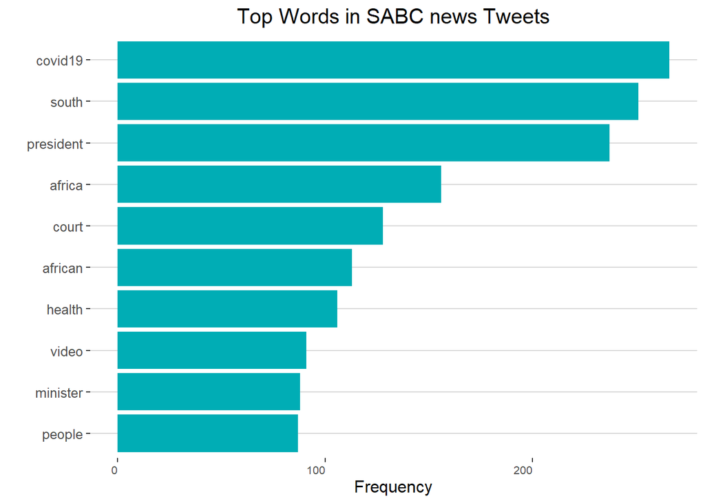

## eNCA (@eNCA)

The eNCA account was chosen because it belongs to the eNCA 24-hour news channel that presents news about South Africa and Africa. The account joined in May 2011.

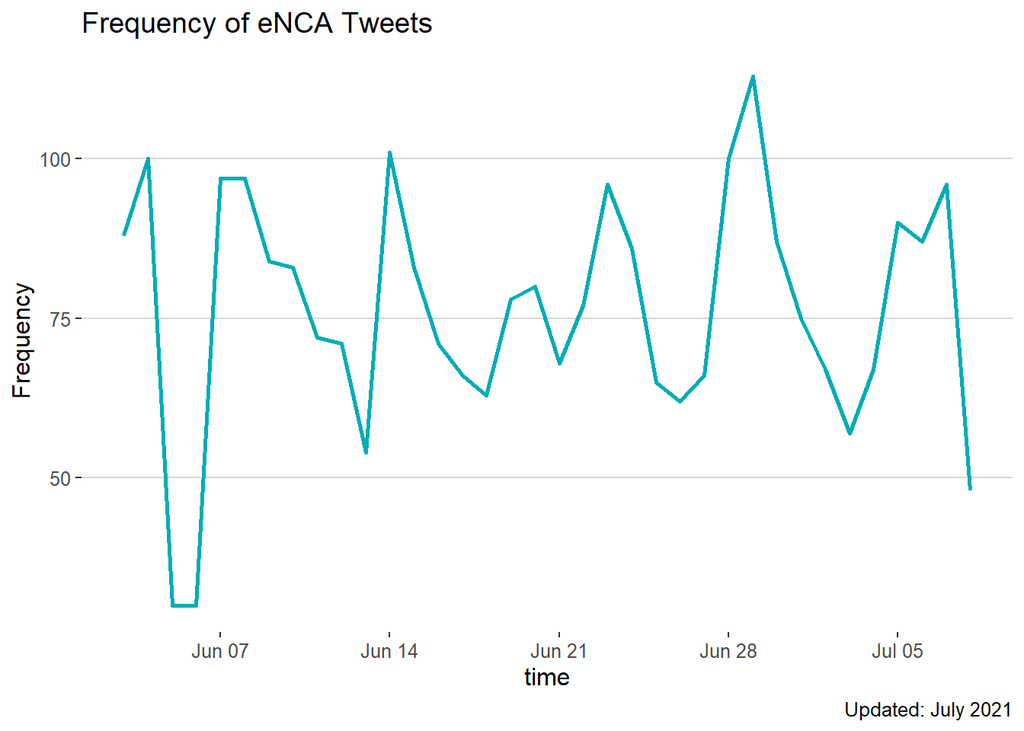

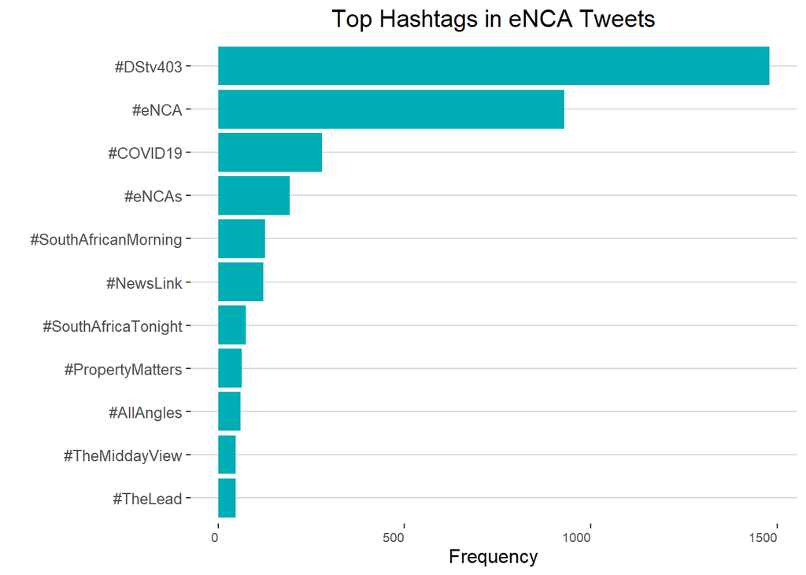

The bar chart showing the top hashtags in eNCA tweets indicates that (in descending order) “#DStv403”, “#eNCA”, “#COVID19”, “#eNCAs”, “#SouthAfricanMorning”, “#NewsLink”, “#SouthAfricaTonight”, “#PropertyMatters”, “#AllAngles”, “#TheMiddayView” and “#TheLead” are their top hashtags. It should be noted that the COVID-19 pandemic ranks third in eNCA’s top hashtags, while the rest of the hashtags refer to either eNCA themself or the respective programmes on their television channel (DSTV403).

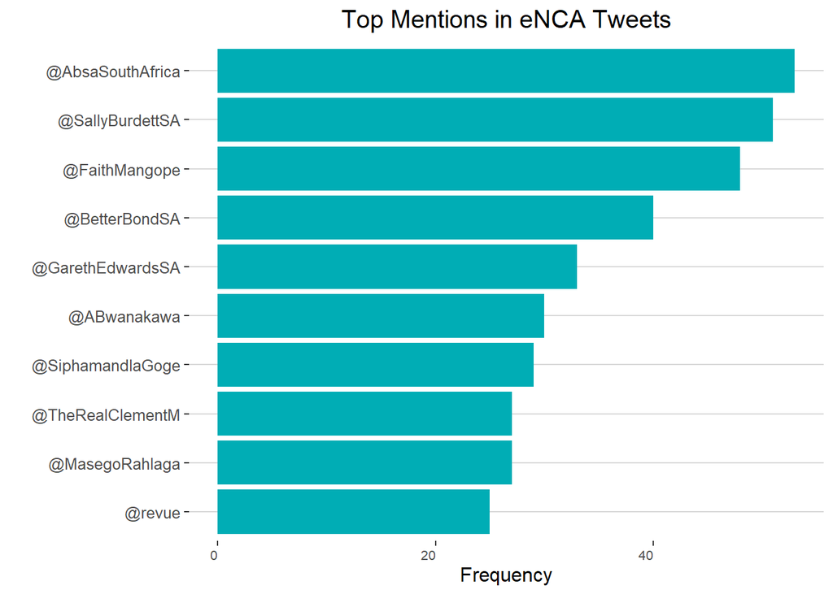

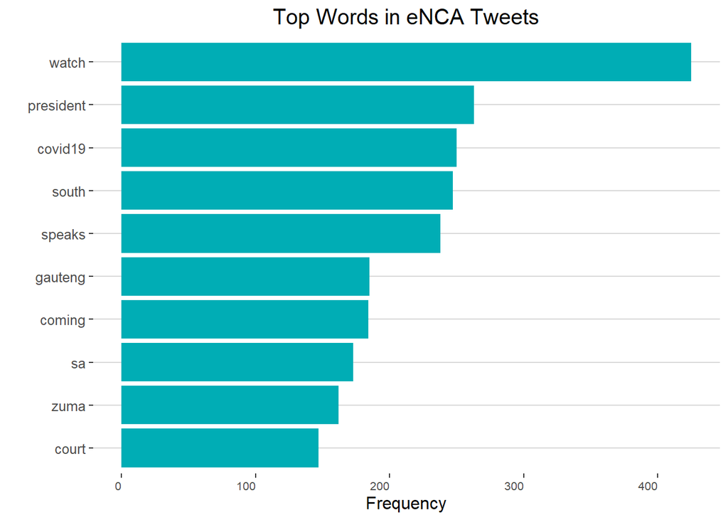

## South African Government (@GovernmentZA)

The South African Government account was chosen because it is an official account of the government, providing accurate and trustworthy information regarding the COVID-19 pandemic and lockdown regulations.

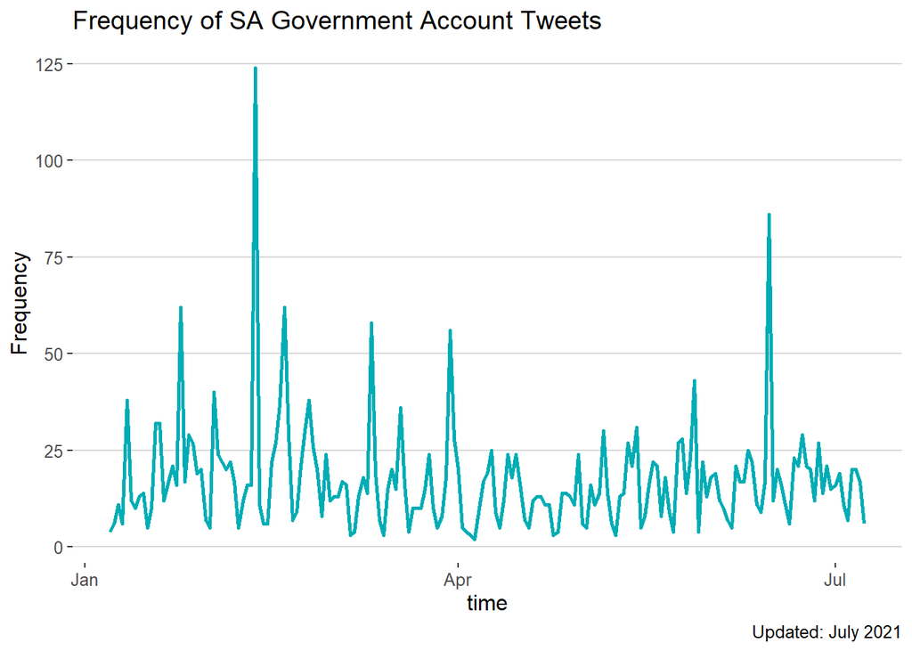

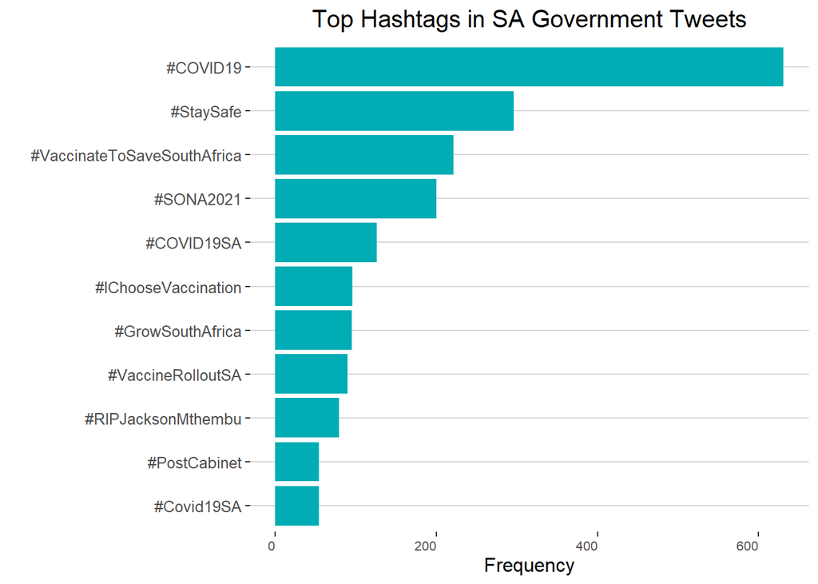

The bar chart showing the top hashtags in SA Government tweets indicates that (in descending order) “#COVID19”, “#StaySafe”, “#VaccinateToSaveSouthAfrica”, “#SONA2021”, “#COVID19SA”, “#ChooseVaccination”, “#GrowSouthAfrica”, “#VaccineRolloutSA”, “#RIP JacksonMthembu”, “PostCabinet” and “#Covid19SA”. From this figure it can be seen that majority of the top terms refer to the COVID-19 pandemic or the vaccination of South Africans.

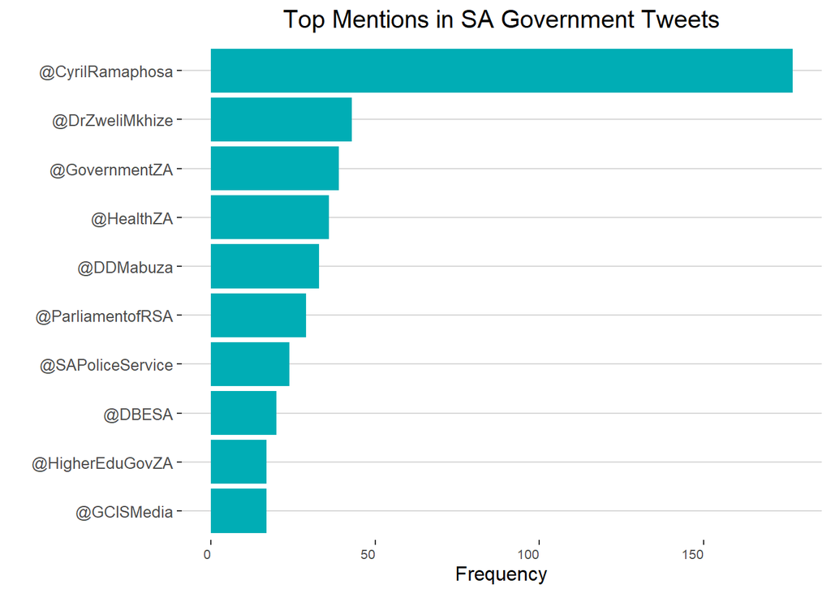

The bar chart showing the top mentions in SA Government tweets indicates that (in descending order) “@CyrilRamaphosa”, “@DrZwelieMkhize”, “@GovvernmentZA”, “@HealthZA”, “@DDMabuza”, “@ParlimentofRSA”, “@SAPoliceService”, “@DBESA”, “@HigherEduGovZA” and “@GCISMedia” are the top mentions in their tweets.

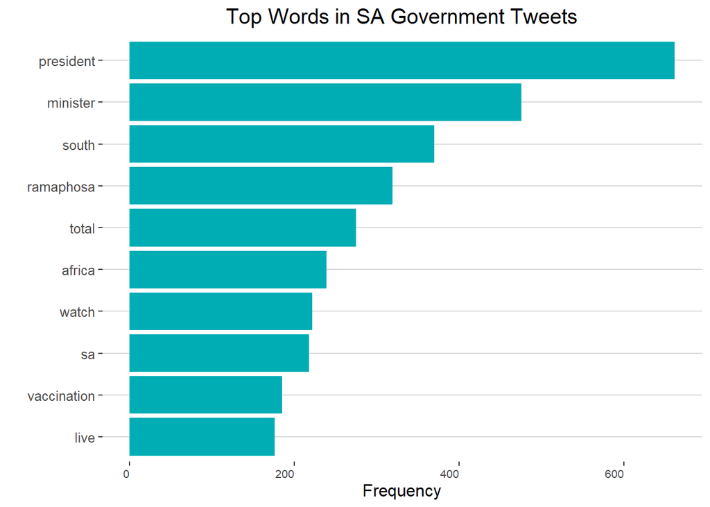

The bar chart showing the top words in SA Government tweets indicate that (in descending order) “president”, “minister”, “south”, “ramaphosa”, “total”, “africa”, “watch”, “sa”, “vaccination” and “live” are the top words used in their tweets. From this figure, it is indicated that the term “vaccination” is an import and prevalent term in the in the SA Government tweets collected.

## South African Government News (@SAgovnews)

Official South African Government News Account on the Twitter Platform.

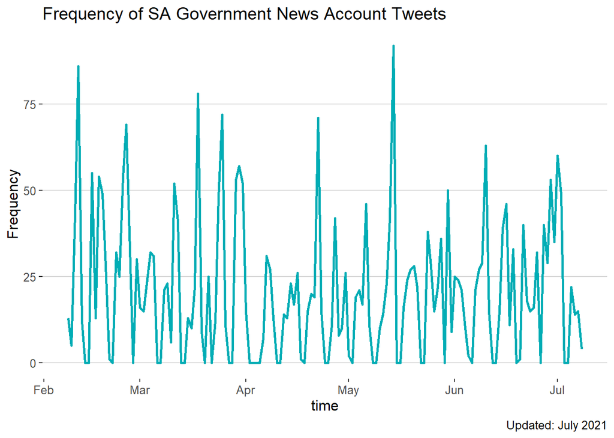

Among the top 5 most liked tweets from the ‘@SAgovnews’ account none seem to hold relevant information on covid 19.

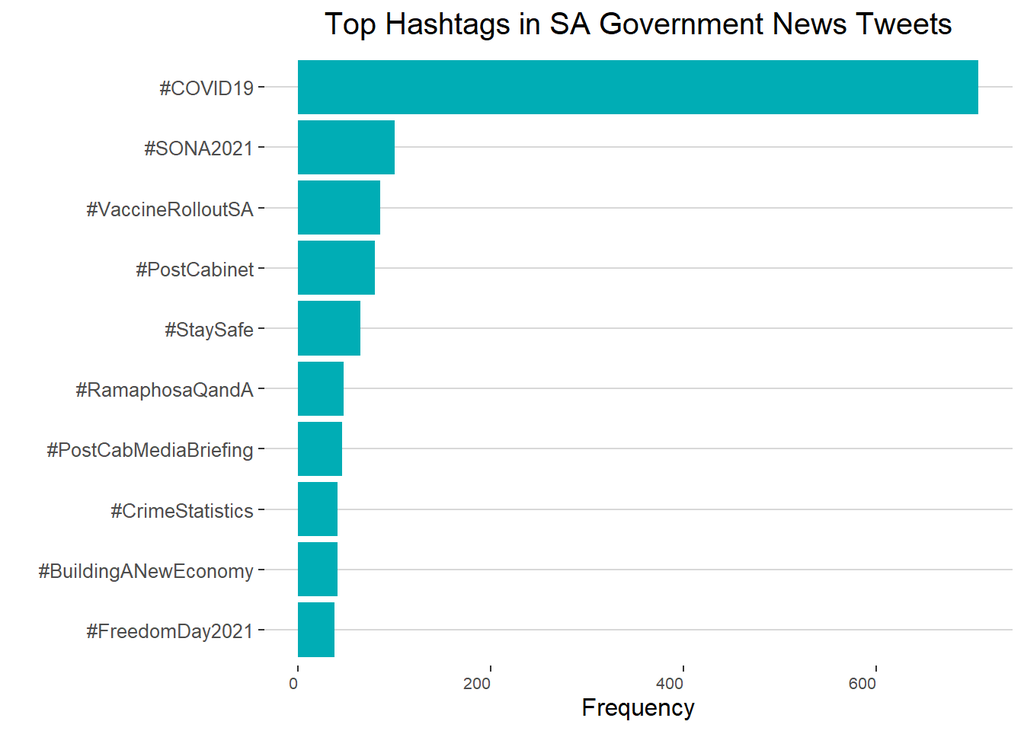

Top hashtags are structured as follows: 1. ‘#COVID19’, 2. ‘#SONA2021’, 3. ‘#VaccineRolloutSA’, 4. ‘#PostCabinet’, 5. ‘#StaySafe’, 6. ‘#RamaphosaQandA’, 7. ‘#PostCabMediaBriefing’, 8. ‘#BuildingANewEconomy’, 9. ‘#CrimeStatistics’ 10. ‘#FreedomDay2021’

The official news agency of the South African Government’s most frequently shared tweet is not relevant to this report.

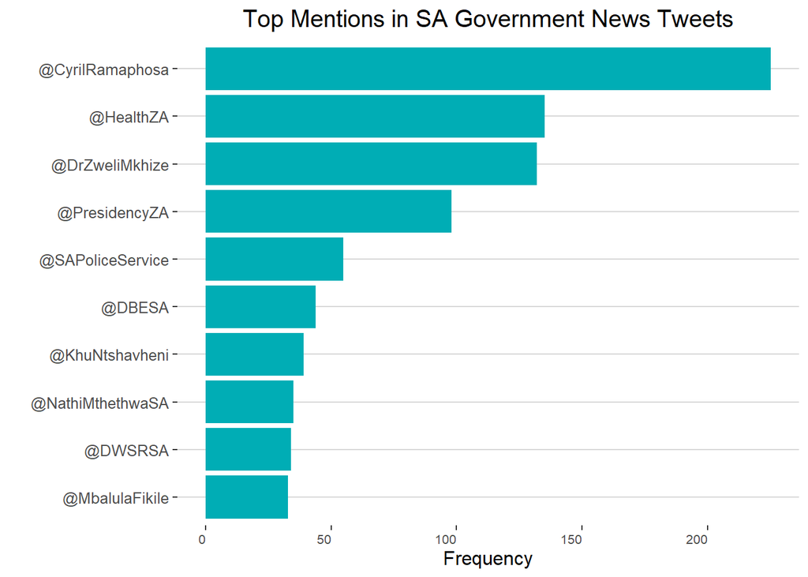

The top mentions within the captured tweets of ‘@SAgovnews’ are: 1. ‘@CyrilRamaphosa’ 2. ‘@HealthZA’ 3. ‘@DrZweliMkhize’ 4. ‘@PresidencyZA’ 5. ‘@SAPoliceService’.

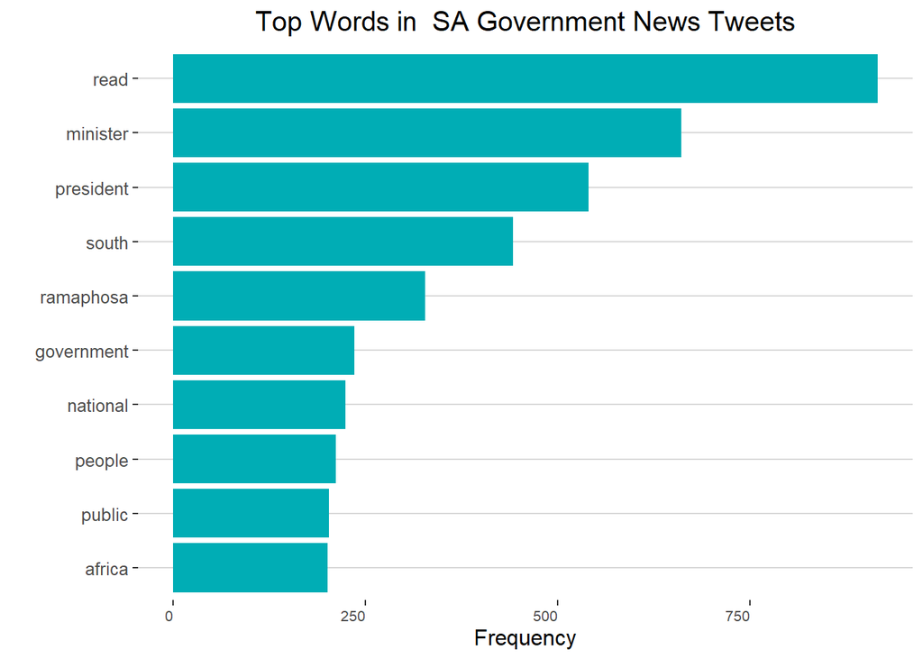

The most frequently used word is ‘read’, due to the account using it as an indication of extended reading material through using “[Read]” in the beginning of certain tweets.

## Health24 (@Health24com)

Health24 is a branch of News24, difference being that they specialise in healthcare related news, whereas News24 takes a more general appraoch.

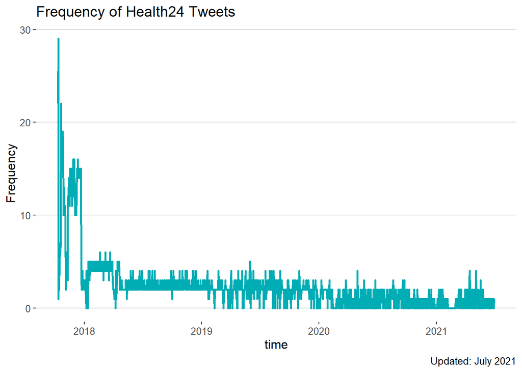

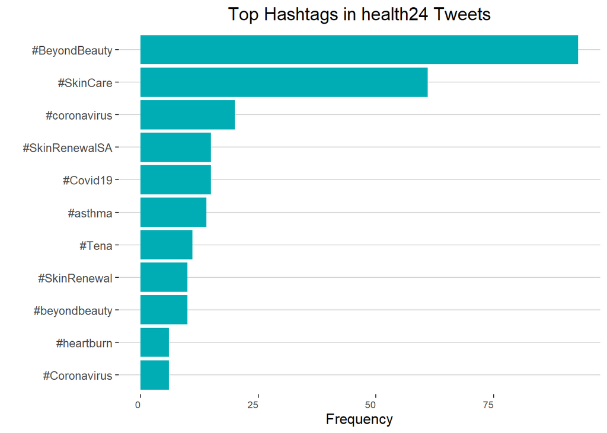

Top hashtags are structured as follows: 1. ‘#BeyondBeauty’, 2. ‘#SkinCare’, 3. ‘#coronavirus’, 4. ‘#Covid19’, 5. ‘#SkinRenewalSA’, 6. ‘#asthma’, 7. ‘#Tena’, 8. ‘#beyondbeauty’, 9. ‘#SkinRenewal’ 10. ‘#Coronavirus’

The most frequently shared tweet concerns the psychological implications on doctors because of the COVID-19 epidemic.

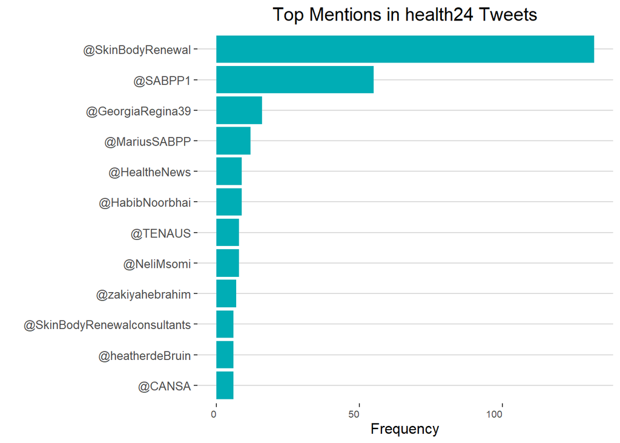

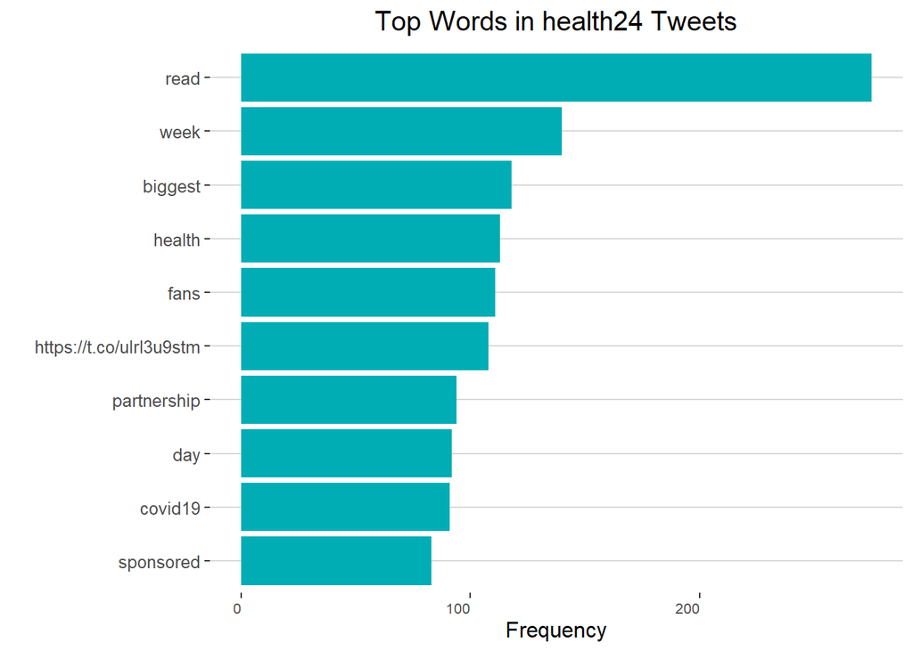

## All Chosen Media Tweet Data Analysis

The following section is the analysis of the all the Twitter accounts combined.

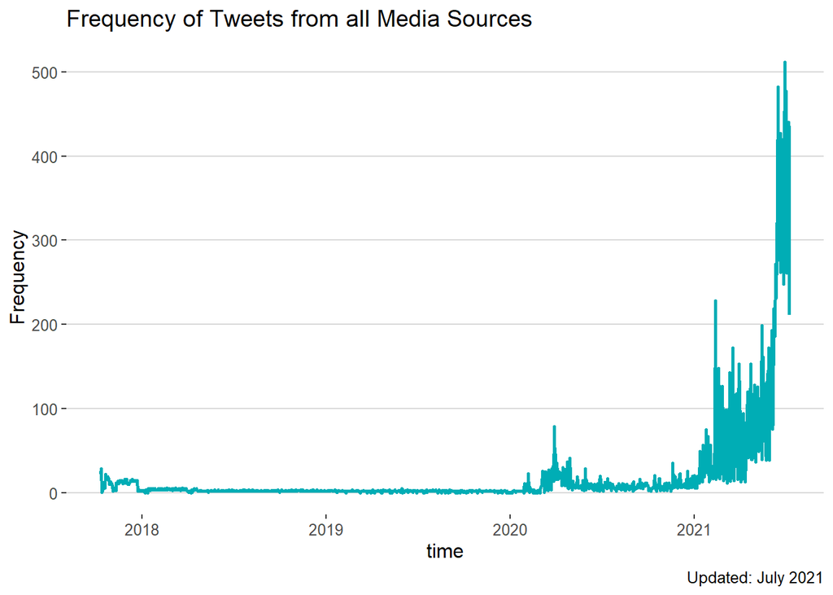

The overall media time series graph shows that the collected tweet data span from the end of 2017 till July 2021. From the start till 2020, the tweet frequency was relatively low, however form the beginning of 2020 there was a large increase tweets. This increase can possibly be attributed to the start of lockdown in South Africa. From the start of 2021 there are even larger increases continuing as time goes by.

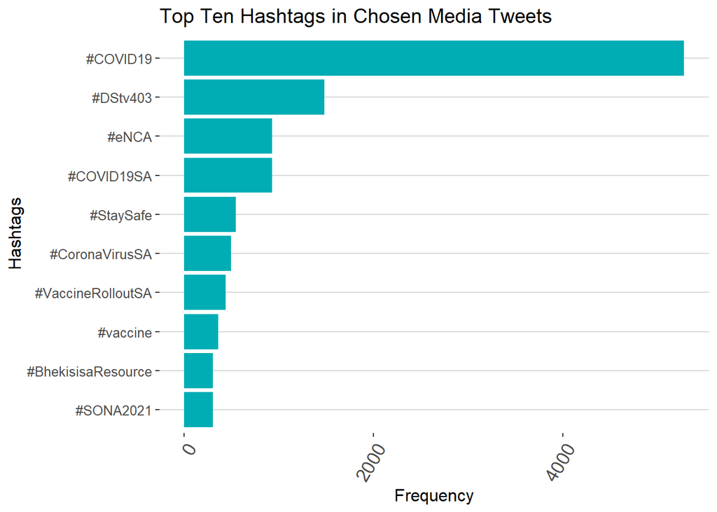

The bar chart showing the top hashtags in overall media tweets indicates that (in descending order) “#COVID19”, “#DSTV403”, “#eNCA”, “#COVID19SA”, “#StaySafe”, “#CoronaVirusSA”, “#VaccineRolloutSA”, “#vaccine”, “#BhekisisaResource” and “SONA2021”. From this figure it should be noted that hashtags pertaining to the COVID-19 pandemic are most prevalent.

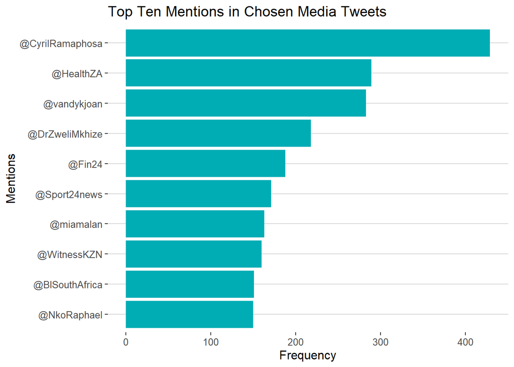

The bar chart showing the top mentions in the overall media tweets indicates that (in descending order) “@CyrilRamaphosa”, “@HealthZA”, “@vandykjoan” ,“@DrZwelieMkhize”, “@Fin24”, “@Sports24news”, “@miamalan”, “@WitnessKZN”, “@BlSouthAfrica” and “@NkoRaphael” are the top mentions in the overall media tweets.

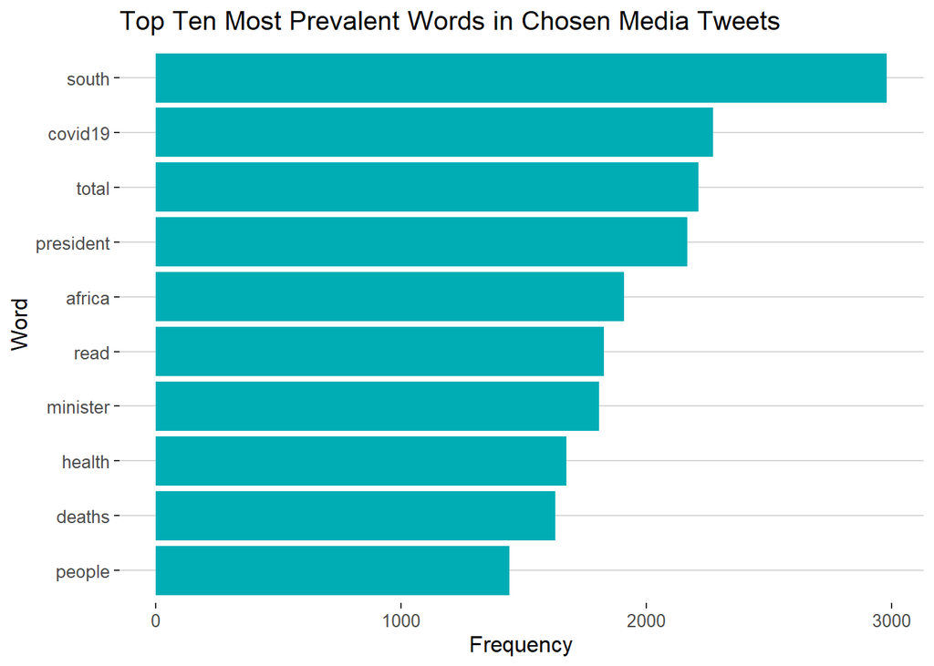

The bar chart showing the top words in the overall tweets indicate that (in descending order) “south”, “covid19”, “total”, “president”, “africa”, “total”, “read”, “minister”, “health”, “deaths” and “people” are the top words used in their tweets. From this figure, it is indicated that the term “covid19” is an import and prevalent term in the in the overall media tweets collected.

## Word Cloud of the Corpus of All Combined Media Sources

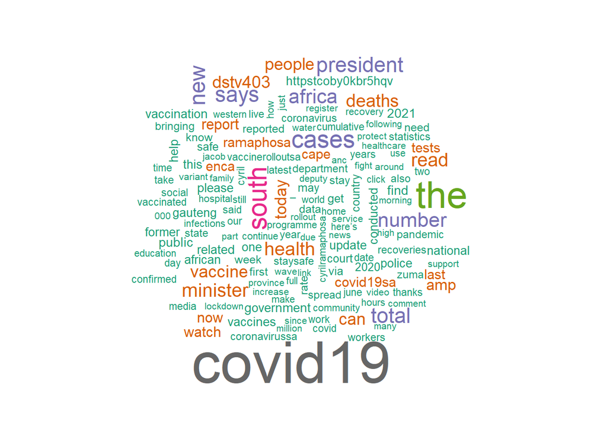

# Topic Modeling

Topic modelling is a type of method used in conducting a text analysis of words grouped together. The method aims to determine the how the meaning of the words is derived from the context of the text. This is not the only method used to analyse grouped words, other examples such as cluster analysis and semantic analysis also exist. The benefits of utilising Topic Modelling include being a mixed model (each document is given a probability of being linked to a topic) and this method makes use of more advanced iterative Bayesian techniques. (Bail, 2020)

## What topics have been reported on:

The main topics reported on are the Covid-19 pandemic, vaccinations and the lockdown in South Africa.

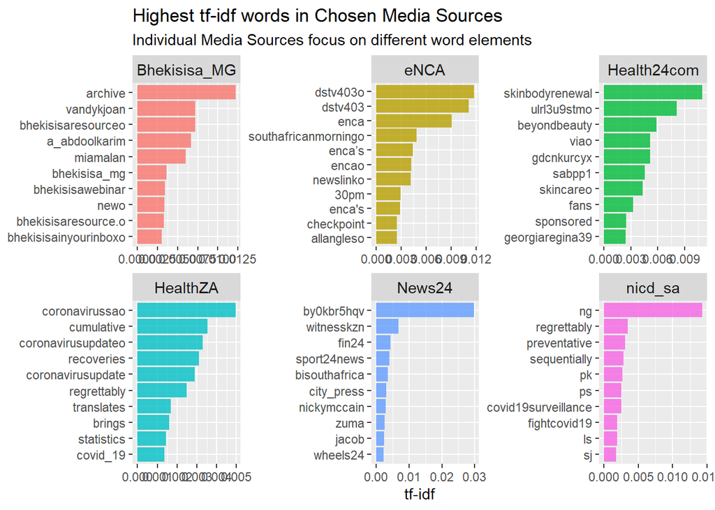

A collection of bar charts showing the words with the highest tf-idf for each of the chosen sources.

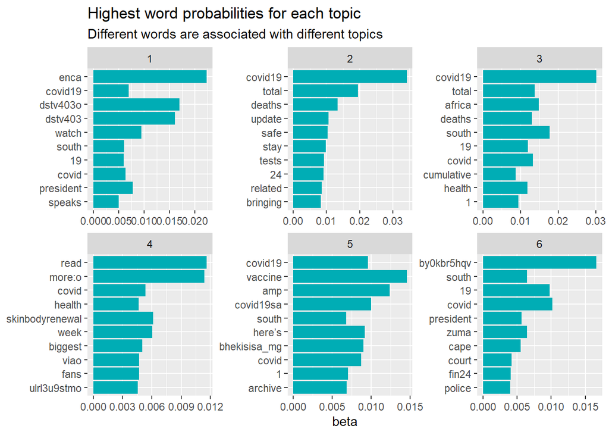

A collection of beta bar charts showing the words with the highest probabilities for each topic.

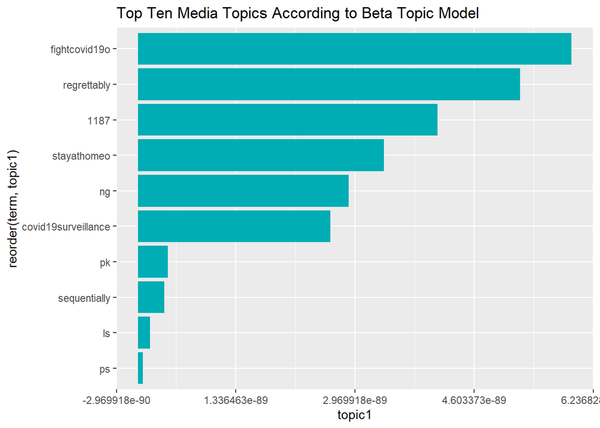

Bar chart showing the top ten media topics according to the Beta Matrix media topic model at Topic 1 probabilities.

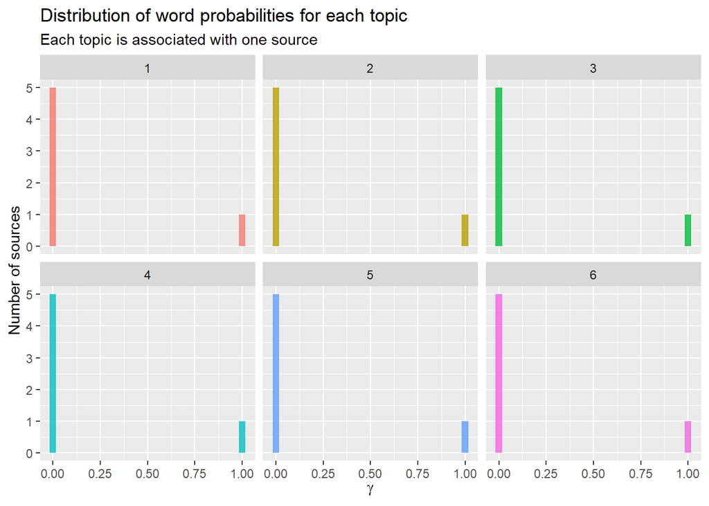

A collection of gamma bar charts showing the distribution of word probabilities for each topic.

# Text Networks

Text Networks are a representation of the relationship between words. These networks are able to represent a corpus of documents or words, where each document or word represents a node and the edges which connect nodes represent how similar words or documents are to each other. In this report, text networks were used to determine how frequent words would occur along side each other, where words represent nodes and edges represent the frequency of the words’ occurrence. (Bail, 2020)

Many benefits exist when using text networks. Text networks help recognise and understand patterns within text and how they are connected. Text networks are workable with text of any length whereas topic modelling only works with short text. By identifying social clusters in texts more insight can be derived from text, as opposed to more simple text analysis techniques.

## Author-based Text Network Modeling of All Media Sources:

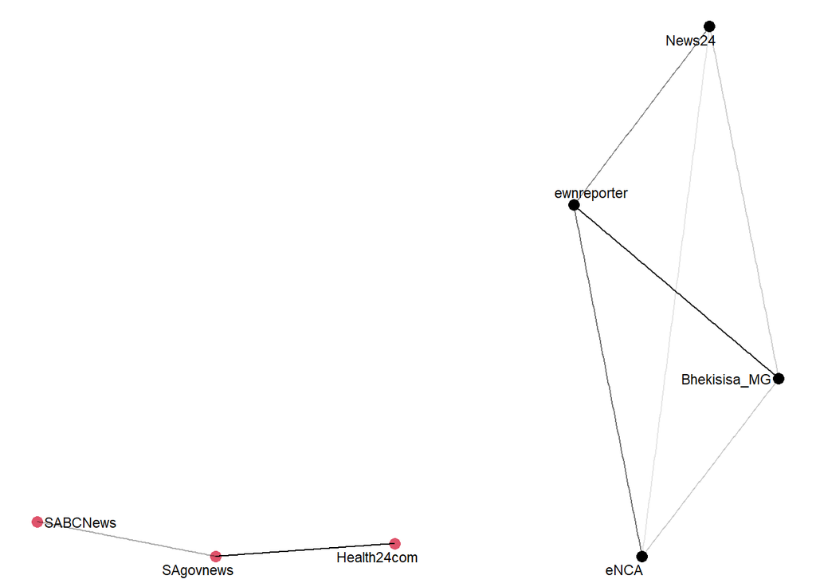

## Word-based Text Network Modeling of All Media Sources:

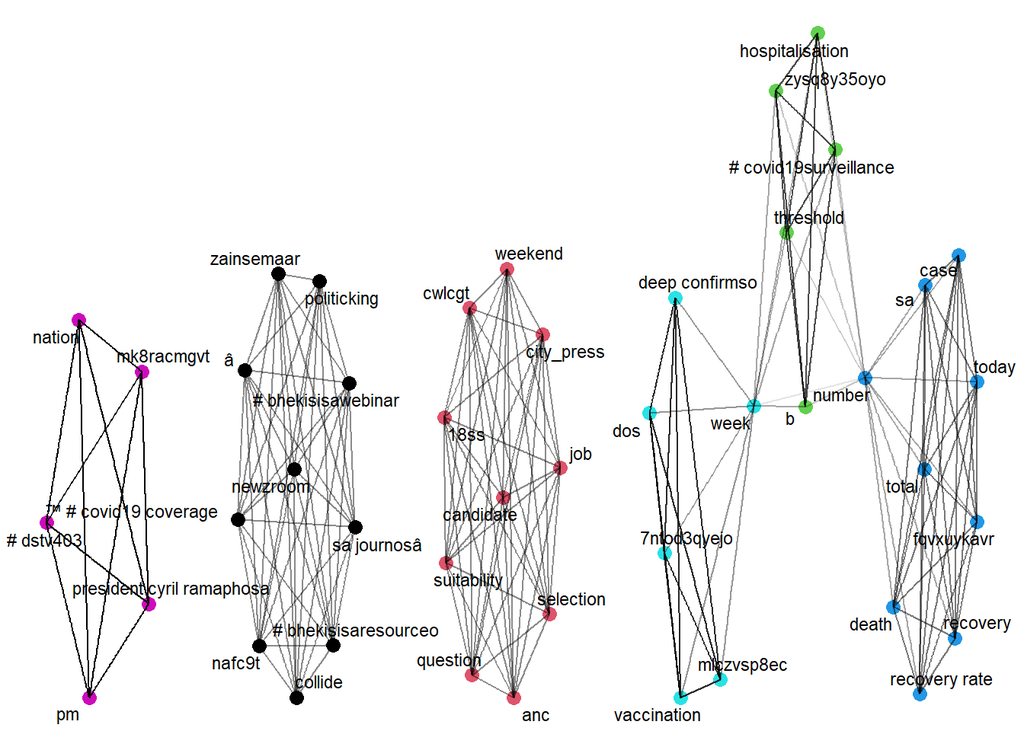

# The Sentiment of this reporting:

Sentiment analysis is the process with which one tries to identify and classify the underlying emotions drawn from a piece of text.The visualisations and descriptions below were documented using the ‘bing’ lexicon, a text-based dictionary, which transcribes and categorises terms in a binary fashion. A plot containing the average sentiment of each of the 6 media sources were chosen to enable a holistic perspective on the data. In viewing these sentiment visualisations, the difference in government media sources to that of private media agencies become apparent. Government sources, like HealthZA (The South African Department of Health) and others, post tweets reflecting that of a more neutral to positive stance, whereas private media agencies post tweets throughout the sentiment spectrum.

# Sentiment Analysis

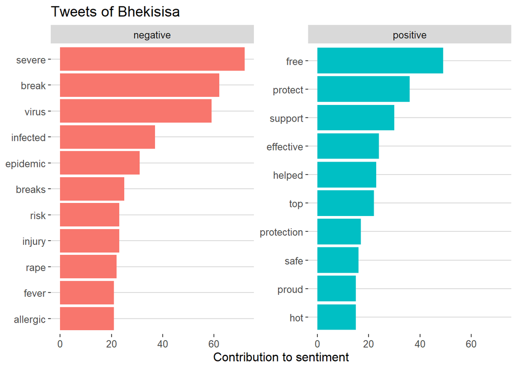

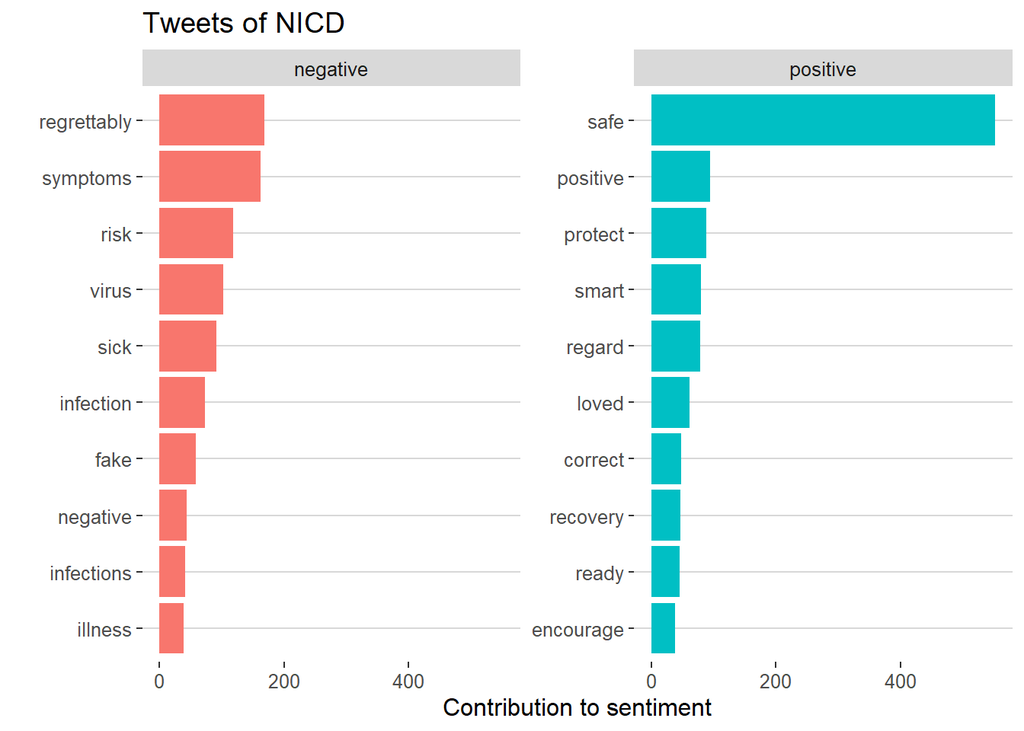

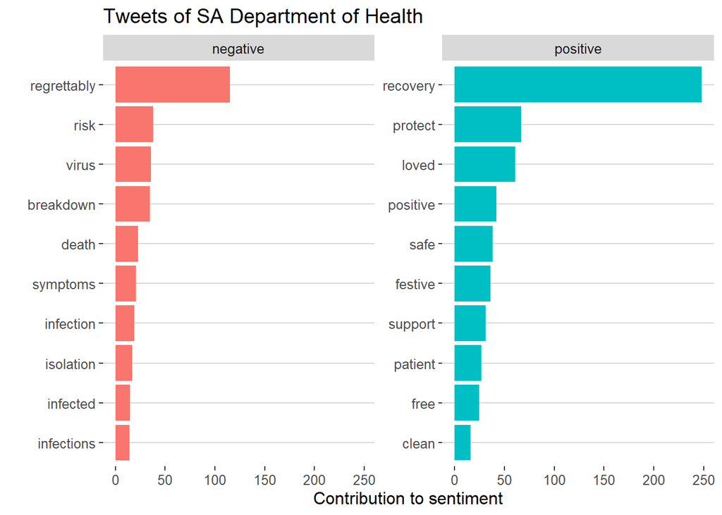

As with the NICD negative sentiment visualisation, ‘regrettably’ seems to be the word carrying the top negative sentiment within in their tweets. Other words are, ‘risk’, ‘virus’, ‘breakdown’, ‘death’, ‘symptoms’, ‘infections’, ‘isolation’, ‘infection’ and ‘infections’. ‘protect’, ‘recovery’, ‘loved’ are the top three most positive words, followed by ‘positive’, ‘safe’, ‘festive’, ‘support’, ‘patient’, ‘free’ and ‘clean’.

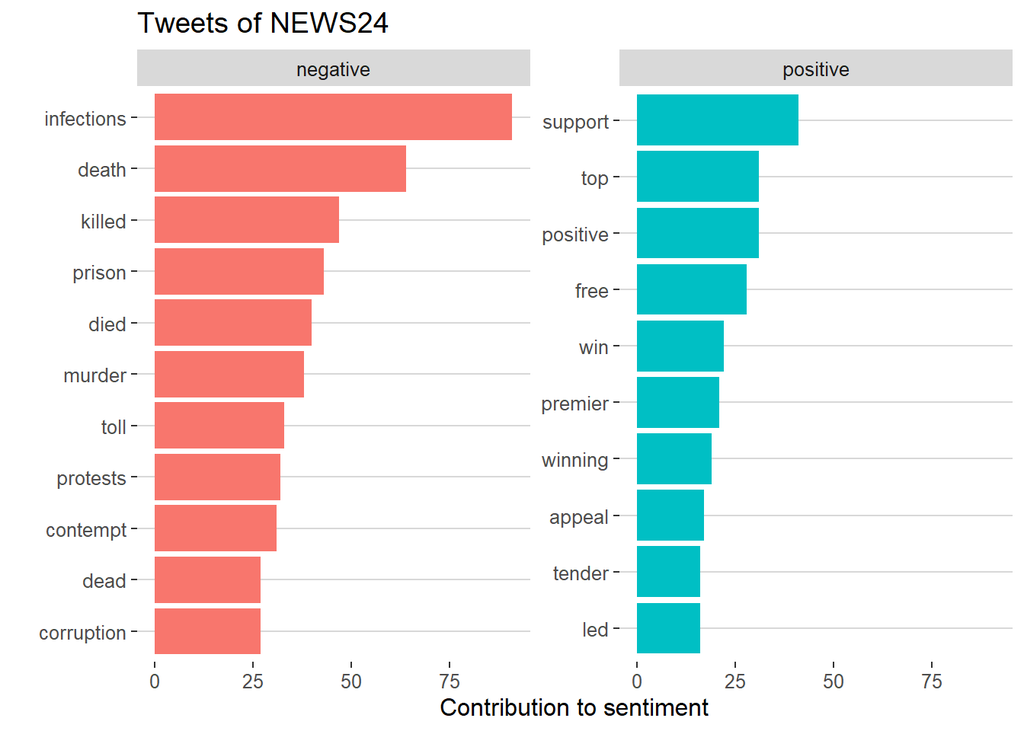

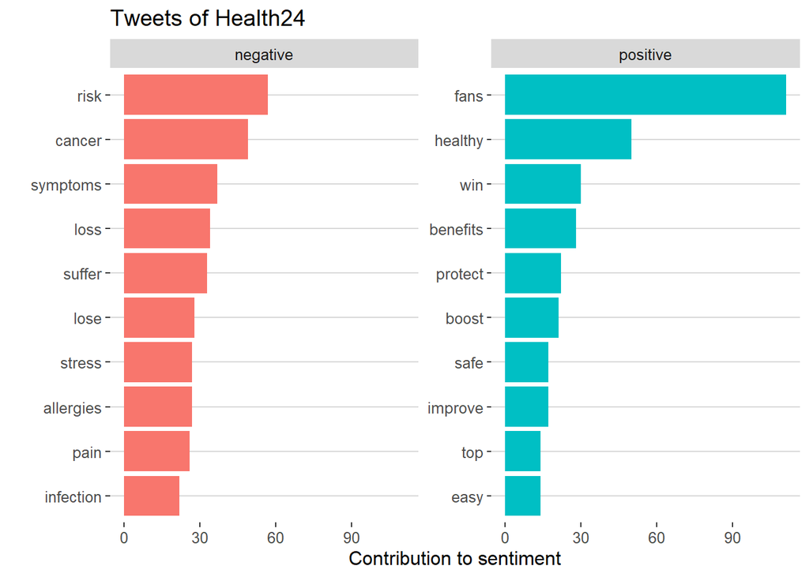

The top negative words from the Health24 twitter handle are ‘risk’, ‘cancer’, ‘symptoms’, ‘loss’, ‘suffer’, ‘lose’, ‘stress’, ‘allergies’, ‘pain’ and ‘infection’. The top positive words from Health24 are ‘fans’, ‘healthy’, ‘win’, ‘benefits’, ‘protect’, ‘boost’, ‘safe’, ‘improve’, ‘top’ and ‘easy’. The great majority of these words are health related.

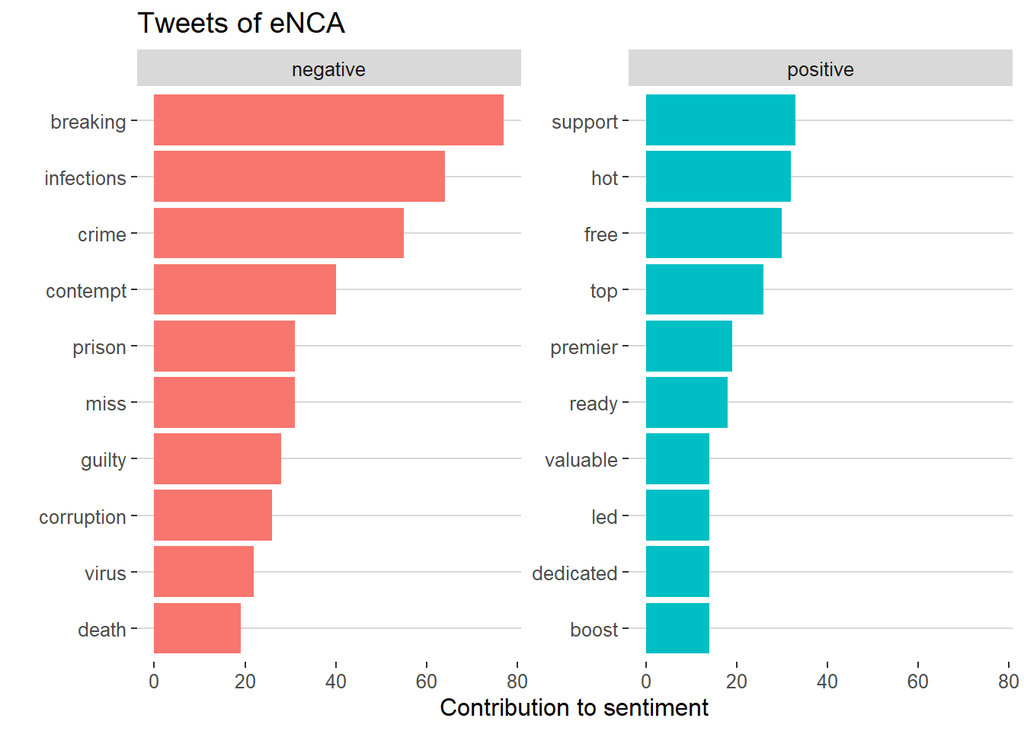

‘breaking’ is the most negative word within the eNCA tweets. ‘infections’, ‘virus’ and ‘death’ are among the top 10 most negative words. ‘support’ ‘hot’ ‘free’ ‘top’ ‘premier’ ‘ready’ ‘valuable’ ‘led’ ‘dedicated’ and ‘boost’ are the ten most positive words.

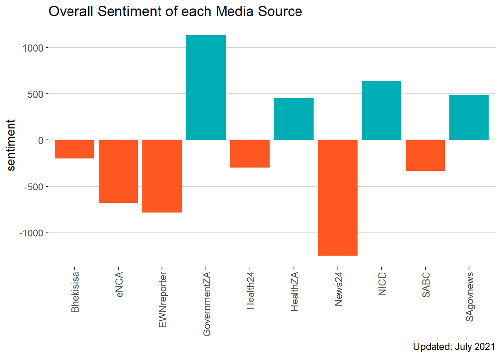

A conclusion can be made that government agencies aim to impose emotions of a more tranquil/positive nature, in opposition to private agencies who solely want to invoke an emotion on any sides of the sentiment spectrum, being that outright negative or outright positive.

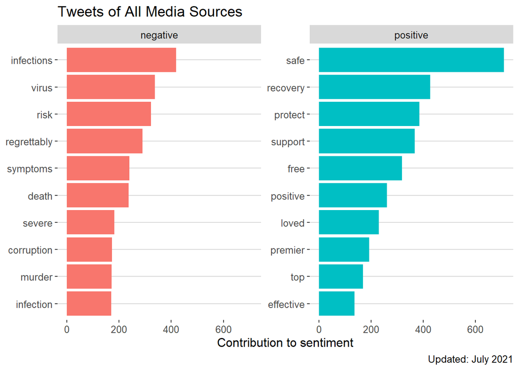

## Comparison Cloud of the Sentiment of Selected Media Sources

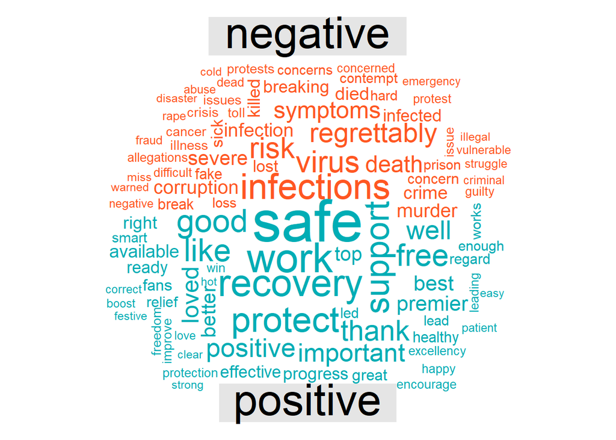

The most significant words potrayed by this analysis is ‘safe’, ‘infections’, ‘work’ and ‘recovery’ which can all be related to the Covid -19 epidemic.